# Mapping in R

Jordan Watson, NOAA Alaska Fisheries Science Center, jordan.watson@noaa.gov

November 28, 2016

Before we dive into the code, a quick warning…err, I mean, uh, introduction…to a piece of syntax that is different when working with shapefiles in R. When you load a shapefile or other spatial object (like a google .kml file) there is a lot of info. Remember that when Arc reads “a” shapefile there are often about a half dozen files associated with that file (e.g., .xml, .shp, .dbf, .prj). Each of these files stores different types of information with different types of attributes. R needs to retain that information if you want to be able to use it. So when you read in a shapefile, it is turned into a spatial object that you could imagine as a really fancy list. It includes the coordinates of each of the vertices of say, an Alaska map. It also needs to include your projection, the attributes and attribute table (your data), and well other stuff that I just don’t really understand.

What I do understand is that these information can not be simply accessed the same way as information in a list. Different pieces of data are kept in different “slots.” A slot can be accessed using the “@” character. You will see this only a few times throughout this file. Particularly, we will access the projection via a slot called “proj4string” via: myshapefile@proj4string. If we wanted to read in a shapefile and then look at the attribute table we would use myshapefile@data. If that yields many results, try head(myshapefile@data).

Here is one of a gazillion sites that explains it better than I do: https://cran.r-project.org/doc/contrib/intro-spatial-rl.pdf

First, we need to get some shapefiles. There are three shapefiles in a zipped folder that can be downloaded here: https://sites.google.com/site/jordantwatson/r/Maps.zip

Entering this link into a web browser should start the download automatically. The AKbasemap.shp shapefile comes from the census bureau (cb_2014_us_state_5m) (https://catalog.data.gov/dataset/2014-cartographic-boundary-file-state-for-united-states-1-5000000)

The EVOS.shop shapefile gives the extent of the Exxon Valdez Oil Spill (EVOS) and was downloaded from the Alaska Ocean Obersving System (AOOS): http://portal.aoos.org/gulf-of-alaska.php#module-metadata/ad71223c-ea24-11e0-95b6-0019b9dae22b/ee8a726e-ea24-11e0-99ff-0019b9dae22b

The final shapefile NCEASRegions.shp is modified from a grid of state statistical management areas and is essentially a custom jobby.

Once you have downloaded the zip folder containing these files, extract each of the three files into your R working directory.

We can test that the files are in the correct location by running the ogrInfo command, where dsn=“.” tells R the path of the file and layer=“AKbasemap” tells R the name of your shapefile. If your shapefile is a “.shp” (as opposed to a .kml or something else) then this convention should work. However, if your file is not in your working directory then “.” will not work and you’ll need to change the path under dsn. Technically “dsn” means “dataset name” but it gets a little confusing here between paths and shapefiles and such. Easiest to just put your shapefiles in your working directory.

“ogr” refers to a shapefile driver so the ogrInfo function reads a shapefile using this driver and gives us some info about the file.

```r
ogrInfo(dsn=".",layer="AKbasemap")
```

```
## Driver: ESRI Shapefile; number of rows: 56
## Feature type: wkbPolygon with 3 dimensions
## Extent: (-179.1473 -14.55255) - (179.7785 71.35256)
## CRS: +proj=longlat +datum=NAD83 +no_defs
## LDID: 0
## Number of fields: 9
##       name type length  typeName
## 1  STATEFP    4      2    String
## 2  STATENS    4      8    String
## 3 AFFGEOID    4     11    String
## 4    GEOID    4      2    String
## 5   STUSPS    4      2    String
## 6     NAME    4    100    String
## 7     LSAD    4      2    String
## 8    ALAND   12     14 Integer64
## 9   AWATER   12     14 Integer64
```

Great, it worked! Now let’s actually do something with this shapefile. Let’s read it in using “readOGR” and save it as akmap.

```r
akmap <- readOGR(dsn=".",layer="AKbasemap")
```

Most of the time, if you got an error message here it’s because the path just isn’t quite right. And then you futz with it for a few hours till you get it right. Super scientific, I assure.

What object class is this magical file?

```r
class(akmap)
```

```
## [1] "SpatialPolygonsDataFrame"
## attr(,"package")
## [1] "sp"
```

What is the projection of the shapefile? We’ll need to make sure that each of the different shapefiles have the same projection.

```r
akmap@proj4string
```

```
## CRS arguments:
##  +proj=longlat +datum=NAD83 +no_defs +ellps=GRS80 +towgs84=0,0,0
```

This is much of the same information that you’d see if you looked at the different files that make up the shapefile (e.g., AKbasemap.shp, AKbasemap.dbf, AKbasemap.prj, AKbasemap.xml…) and you opened the .prj file. Or similarly if, in your GIS program like Arc or qGIS you looked at the properties of the layer.

Now, let’s convert this to a ggplot / data frame object for mapping using the “tidy” function (we could also use “fortify” but it will be replaced / deprecated in the next few years so I’ll stick with “tidy” instead).

```r
#  Convert the object to a ggmap object
ak <- tidy(akmap)
#  Now what is the class of the object?
class(ak)
```

```
## [1] "data.frame"
```

```r
#  What are the names of our fields in the data.frame?
head(ak)
```

```
##        long      lat order  hole piece group id
## 1 -114.7997 32.59362     1 FALSE     1   0.1  0
## 2 -114.8094 32.61712     2 FALSE     1   0.1  0
## 3 -114.7976 32.62458     3 FALSE     1   0.1  0
## 4 -114.7822 32.63021     4 FALSE     1   0.1  0
## 5 -114.7649 32.64939     5 FALSE     1   0.1  0
## 6 -114.7305 32.69884     6 FALSE     1   0.1  0
```

```r
#  When we plot, we need to know that our coordinates are called "long" and "lat"
#  and that polygons are called "group" for this shapefile.
map1 <- ggplot() +
  geom_polygon(data=ak,aes(x=long,y=lat,group=factor(group))) + theme_bw()
```

We obviously need to set some bounds on our map. It’ll be easier if we just set those bounds as some name and then if we update those bounds we can update them in many places by just changing them once.

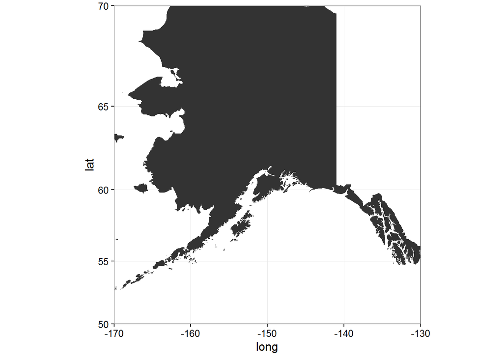

```r
xmin <- -170
xmax <- -130
ymin <- 50
ymax <- 70

map1 + coord_map(xlim=c(xmin,xmax),ylim=c(ymin,ymax))
```

Okay, it looks a little silly with Canada missing. Let’s pull in one of the Canada shapefiles that are built in the R maps packages.

```r
library(maps)
library(mapdata)
#  This will make sure the high res data set is loaded
data("world2HiresMapEnv")
```

There is a ggmap function called “map_data” that converts the built-in spatial objects into a data frame that can be easily plotted using ggplot. If we peek at the world2Hires dataset we will see a field called “region” that appears to contain country names. So in this case we can just subset world2Hires by specifying that we want the “canada” region.

```r
#  Convert the dataset to a data frame
canada=map_data("world2Hires",region="canada")
```

I’m not going to worry about the projection because this part is just background filler.

```r
#  Let's make sure we know what the fields are called.
head(canada)
```

```
##       long      lat group order region subregion
## 1 226.6336 58.42416     1     1 Canada      <NA>
## 2 226.6314 58.42336     1     2 Canada      <NA>
## 3 226.6122 58.41196     1     3 Canada      <NA>
## 4 226.5911 58.40027     1     4 Canada      <NA>
## 5 226.5719 58.38864     1     5 Canada      <NA>
## 6 226.5528 58.37724     1     6 Canada      <NA>
```

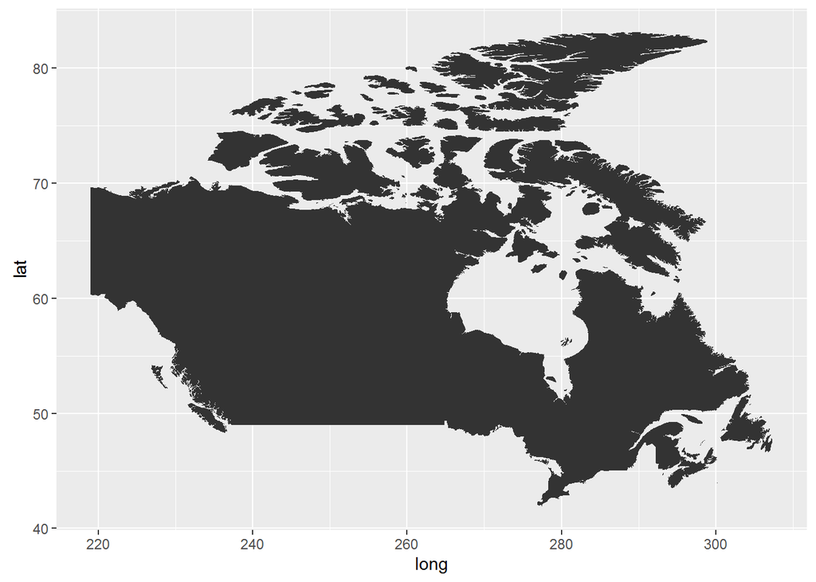

```r
#  Let's make sure it looks like Canada
ggplot() + geom_polygon(data=canada,aes(long,lat,group=factor(group)))
```

Now let’s add this to our Alaska map, putting in a “color” argument which changes the outline color and provides us with a border

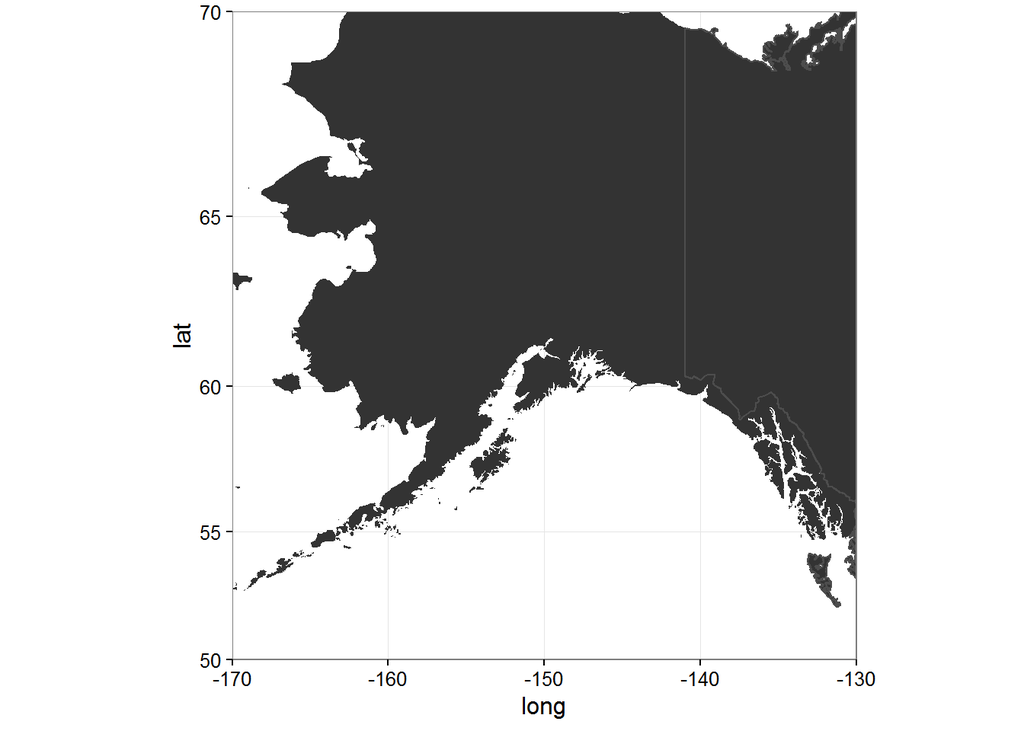

```r
map1 +
  geom_polygon(data=canada,
               aes(long,lat,group=factor(group)),
               color="grey30") +
  coord_map(xlim=c(xmin,xmax),ylim=c(ymin,ymax))
```

Okay, so now we have combined our custom shapefile with one of the built-in R spatial datasets. Neat.

Let’s start to build our custom map now. In this case, let’s first add a shapefiles that shows the extent of the EVOS.

```r
evos <- readOGR(dsn=".",layer="EVOS")
```

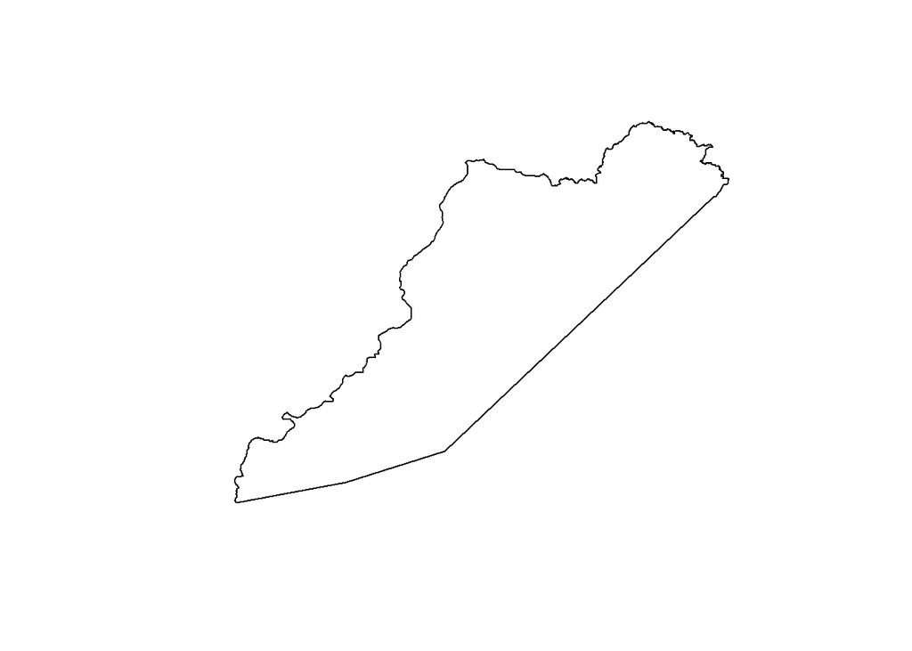

```r
#  What does this layer look like?
plot(evos)
```

We need to make sure that the projection of this shapefile matches that of our basemap.

```r
evos@proj4string
```

```
## CRS arguments:
##  +proj=longlat +datum=WGS84 +no_defs +ellps=WGS84 +towgs84=0,0,0
```

```r
#  Hmm, that's a lot to compare so let's just ask R to see if they are identical
identical(evos@proj4string,akmap@proj4string)
```

```
## [1] FALSE
```

```r
#  We could transform the projection by using the spTranform function and manually spelling out the new CRS
#  (coordinate reference system) that we want (see ?spTransform). But let's be smart. We know we just want to match
#  that of our basemap projection. So let's just tell it our source shapefile (evos) and our new projection
#  (which should match akmap@proj4string)
evos2 <- spTransform(evos,akmap@proj4string)

#  Now let's see if evos2@proj4string is the same as akmap@proj4string
identical(evos2@proj4string,akmap@proj4string)
```

```
## [1] TRUE
```

Neat!!! Now let’s convert evos into a data frame and plot it.

```r
evoslayer <- tidy(evos2)
head(evoslayer)
```

```
##        long      lat order  hole piece group id
## 1 -159.6418 55.89420     1 FALSE     1   0.1  0
## 2 -159.6405 55.90176     2 FALSE     1   0.1  0
## 3 -159.6386 55.90910     3 FALSE     1   0.1  0
## 4 -159.6343 55.91914     4 FALSE     1   0.1  0
## 5 -159.6304 55.92612     5 FALSE     1   0.1  0
## 6 -159.6262 55.93147     6 FALSE     1   0.1  0
```

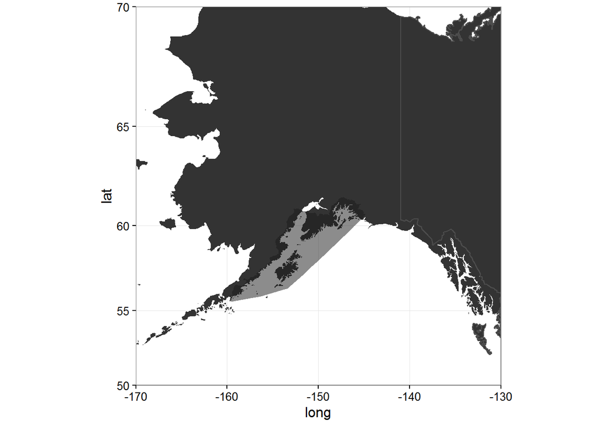

```r
map1 +
  geom_polygon(data=canada,
               aes(long,lat,group=factor(group)),
               color="grey30") +
  geom_polygon(data=evoslayer,
               aes(x=long,y=lat,group=factor(group)),
               fill="gray10",
               alpha=0.5) +
  coord_map(xlim=c(xmin,xmax),ylim=c(ymin,ymax))
```

If we just add the new polygon it adds it on top of the map but we want it to slide underneath the map for better continuity because we are fisheries people and mostly we’re interested in the marine parts of the EVOS effects.

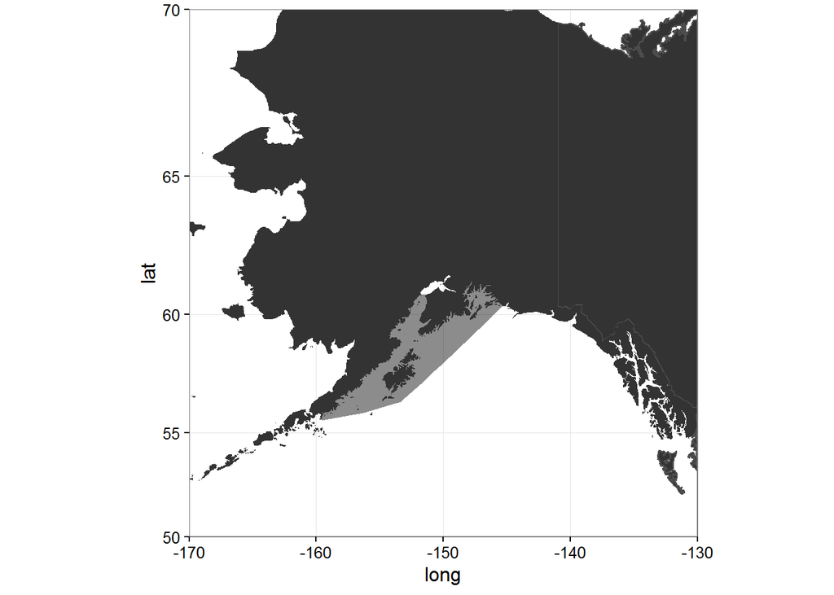

```r
ggplot() +
  geom_polygon(data=canada,
               aes(long,lat,group=factor(group)),
               color="grey30") +
  geom_polygon(data=evoslayer,
               aes(x=long,y=lat,group=factor(group)),
               fill="gray10",
               alpha=0.5) +
  geom_polygon(data=ak,
               aes(x=long,y=lat,group=factor(group))) +
  coord_map(xlim=c(xmin,xmax),ylim=c(ymin,ymax)) +
  theme_bw()
```

Now let’s add one more layer to the mix.

```r
nceas <- readOGR(dsn=".",layer="NCEASRegions")
```

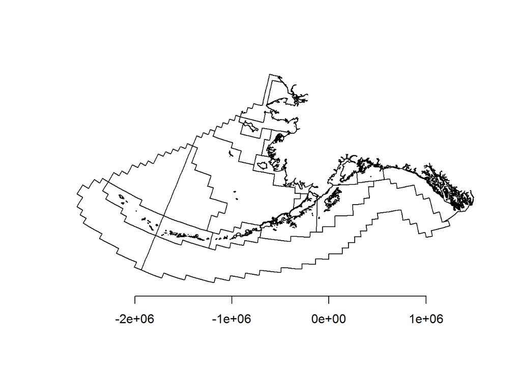

```r
plot(nceas);axis(1)
```

Before we transform the shapefile, let’s first look at the data (the .dbf part) that you’d find in the attribute field of a shapefile.

```r
nceas@data
```

```
##           NCEAS_Area
## 0   Alaska Peninsula
## 1         Bering Sea
## 2        Bristol Bay
## 3         Cook Inlet
## 4  Eastern Aleutians
## 5             Kodiak
## 6           Kotzebue
## 7          Kuskokwim
## 8       Norton Sound
## 9                PWS
## 10       SEAK Inside
## 11      SEAK Outside
## 12        Unassigned
## 13 Western Aleutians
## 14             Yukon
```

```r
#  Okay, we see here that there are 15 different regions or polygons.
#  Let's select only certain ones that we want to plot.
nceas <- nceas[nceas@data$NCEAS_Area %in% c("Alaska Peninsula","Bristol Bay","Cook Inlet","Kodiak","PWS","SEAK Inside"),]
```

In the shapefile part of the nceas file, the region attribute is just a number (or character representation of a number). So if we plot all of these regions and we want a legend, it’s going to label the legend with these region numbers instead of the names that we see in the attribute table. So let’s create a data frame that will allow us to link the numeric representations with the text labels.

```r
mylabs <- data.frame(nceas@data,id=(as.character(rownames(nceas@data))))
```

And now let’s see what this thing looks like

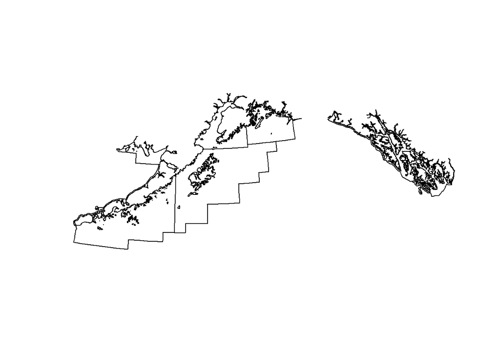

```r
plot(nceas)
```

Let’s go through the same projection and data frame business as before.

```r
nceas@proj4string
```

```
## CRS arguments:
##  +proj=aea +lat_1=55 +lat_2=65 +lat_0=50 +lon_0=-154 +x_0=0 +y_0=0
## +datum=NAD83 +units=m +no_defs +ellps=GRS80 +towgs84=0,0,0
```

```r
identical(nceas@proj4string,akmap@proj4string)
```

```
## [1] FALSE
```

```r
nceas2 <- spTransform(nceas,akmap@proj4string)

identical(nceas2@proj4string,akmap@proj4string)
```

```
## [1] TRUE
```

```r
nceas2@proj4string
```

```
## CRS arguments:
##  +proj=longlat +datum=NAD83 +no_defs +ellps=GRS80 +towgs84=0,0,0
```

```r
#  Convert to a data.frame
nceas2 <- tidy(nceas2) %>% left_join(mylabs)
#  Make sure the fields are called the same thing.
head(nceas2)
```

```
##        long      lat order  hole piece group id       NCEAS_Area
## 1 -157.6172 57.97989     1 FALSE     1   0.1  0 Alaska Peninsula
## 2 -157.6161 57.97848     2 FALSE     1   0.1  0 Alaska Peninsula
## 3 -157.6161 57.97704     3 FALSE     1   0.1  0 Alaska Peninsula
## 4 -157.6156 57.97591     4 FALSE     1   0.1  0 Alaska Peninsula
## 5 -157.6156 57.97478     5 FALSE     1   0.1  0 Alaska Peninsula
## 6 -157.6150 57.97363     6 FALSE     1   0.1  0 Alaska Peninsula
```

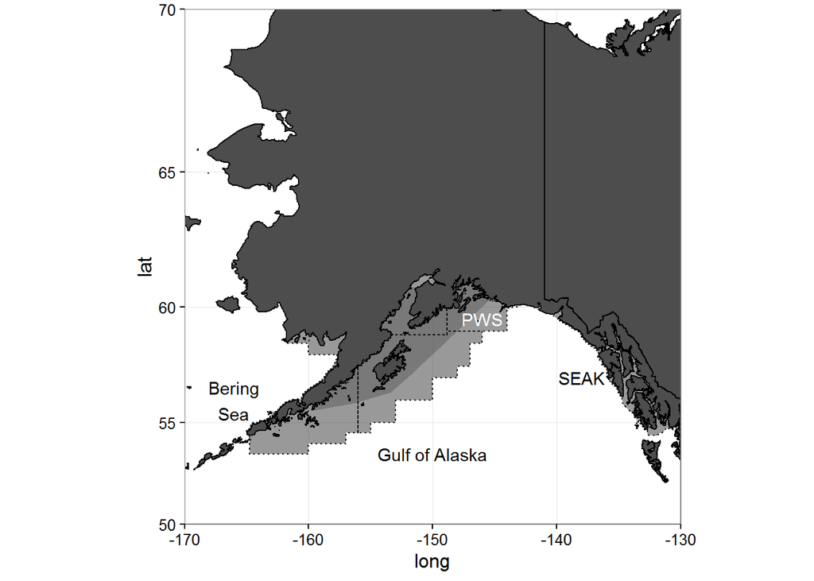

```r
#  It'll take a few tries to get the order of the polygons right, but with some tweaking we can get...
ggplot() +
  geom_polygon(data=canada,
               aes(long,lat,group=factor(group)),
               fill="gray30",
               color="black") +
  geom_polygon(data=evoslayer,
               aes(x=long,y=lat,group=factor(group)),
               fill="gray50",
               alpha=0.5) +
  geom_polygon(data=nceas2,
               aes(x=long,y=lat,group=factor(group)),
               fill="gray20",
               color="black",
               linetype=3,
               alpha=0.5) +
  geom_polygon(data=ak,
               aes(x=long,y=lat,group=factor(group)),
               fill="gray30",
               color="black") +
  coord_map(xlim=c(xmin,xmax),ylim=c(ymin,ymax)) +
  theme_bw() +
  annotate("text", x = -150, y = 53.5, label = "Gulf of Alaska") +
  annotate("text", x = -166, y = 56, label = "Bering\nSea") +
  annotate("text", x = -138, y = 57, label = "SEAK") +
  annotate("text", x = -146, y = 59.5, label = "PWS",color="white")
```

Notice that I’ve made a number of subtle formatting changes here as well. Adjusting transparencies and adding some text labels.

We could also do a version of this plot in grayscale.

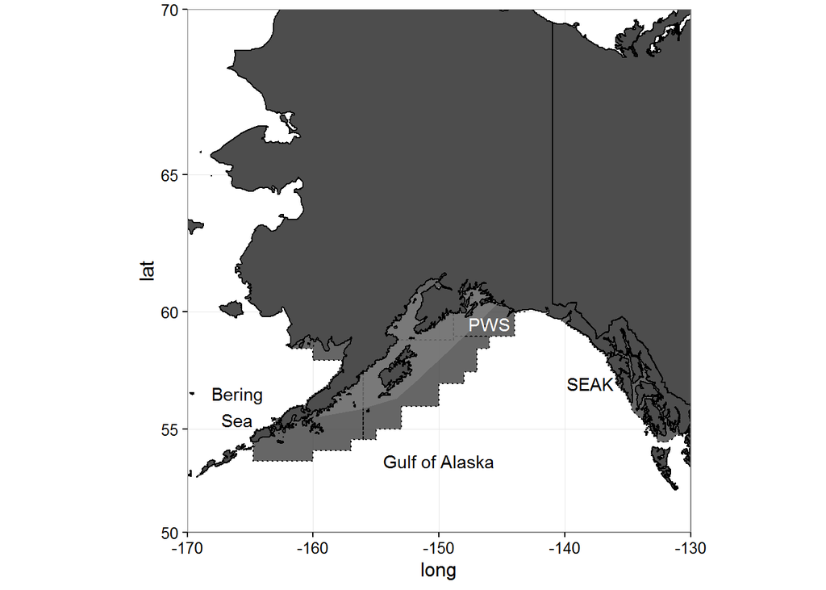

```r
bw.map <- ggplot() +
  geom_polygon(data=canada,
               aes(long,lat,group=factor(group)),
               fill="gray30",
               color="black") +
  geom_polygon(data=nceas2,
               aes(x=long,y=lat,group=factor(group)),
               fill="gray20",
               color="black",
               linetype=3,
               alpha=0.75) +
  geom_polygon(data=evoslayer,
               aes(x=long,y=lat,group=factor(group)),
               fill="gray50",
               alpha=0.75) +
  geom_polygon(data=ak,
               aes(x=long,y=lat,group=factor(group)),
               fill="gray30",
               color="black") +
  coord_map(xlim=c(xmin,xmax),ylim=c(ymin,ymax)) +
  theme_bw() +
  annotate("text", x = -150, y = 53.5, label = "Gulf of Alaska") +
  annotate("text", x = -166, y = 56, label = "Bering\nSea") +
  annotate("text", x = -138, y = 57, label = "SEAK") +
  annotate("text", x = -146, y = 59.5, label = "PWS",color="white")

bw.map
```

Or a color version that brings in regional attributes and a legend.

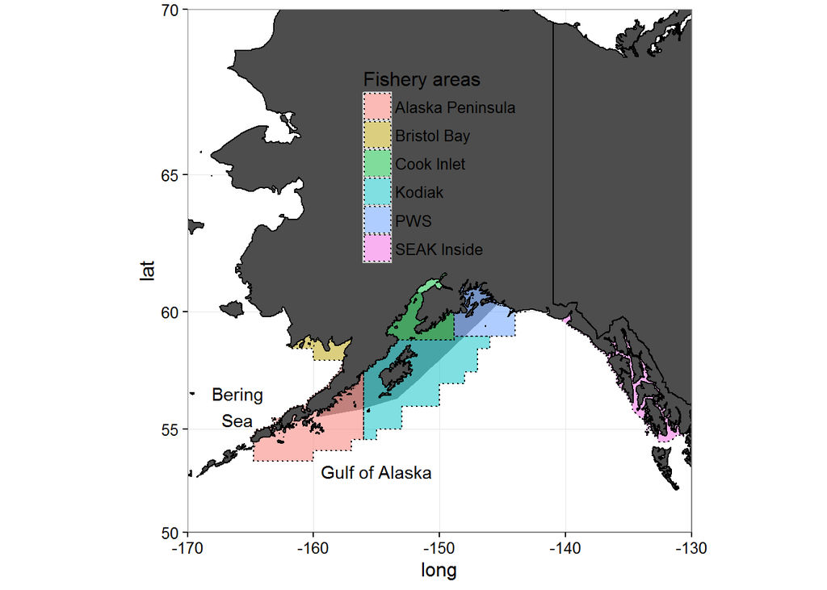

```r
my.map <- ggplot() +
  geom_polygon(data=canada,
               aes(long,lat,group=factor(group)),
               fill="gray30",
               color="black") +
  geom_polygon(data=evoslayer,
               aes(x=long,y=lat,group=factor(group)),
               fill="gray50",
               alpha=0.9) +
  geom_polygon(data=nceas2,
               aes(x=long,y=lat,group=factor(group),fill=factor(NCEAS_Area)),
               color="black",linetype=3,alpha=0.5) +
  geom_polygon(data=ak,aes(x=long,y=lat,group=factor(group)),
               fill="gray30",
               color="black") +
  annotate("text", x = -155, y = 53, label = "Gulf of Alaska") +
  annotate("text", x = -166, y = 56, label = "Bering\nSea") +
  coord_map(xlim=c(xmin,xmax),ylim=c(ymin,ymax)) +
  theme_bw() +
  theme(legend.position = c(0.5, 0.7),legend.background=element_blank()) +
  labs(fill="Fishery areas")

my.map
```

# Inset

Now let’s add an inset to our map. First using a built-in spatial dataset from the PBSmapping package.

```r
library(PBSmapping)
#  Load the nepacLLhigh dataset
data(nepacLLhigh)

#  Check the class of this dataset
class(nepacLLhigh)
```

```
## [1] "PolySet"    "data.frame"
```

```r
#  What do the fields look like?
head(nepacLLhigh)
```

```
##   PID POS         X        Y
## 1   0   1 -180.0032 68.99547
## 2   0  10 -180.0249 68.99956
## 3   0  17 -180.0299 69.00289
## 4   0  22 -180.0516 69.00458
## 5   0  40 -180.0884 69.01289
## 6   0  53 -180.1166 69.02542
```

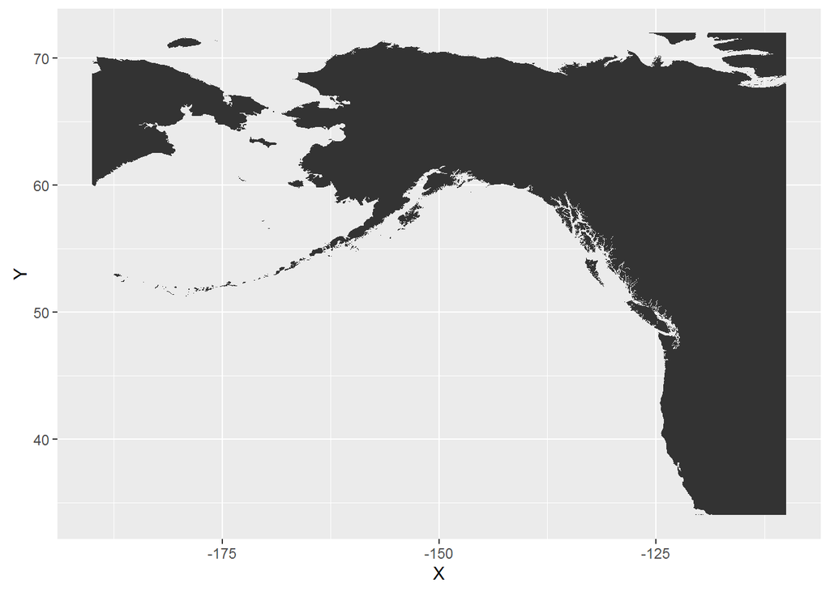

```r
#  Let's plot it
ggplot() + geom_polygon(data=nepacLLhigh,aes(x=X,y=Y,group=PID))
```

Just as we had set spatial boundaries for our primary map, let’s set some boundaries for what will become our inset.

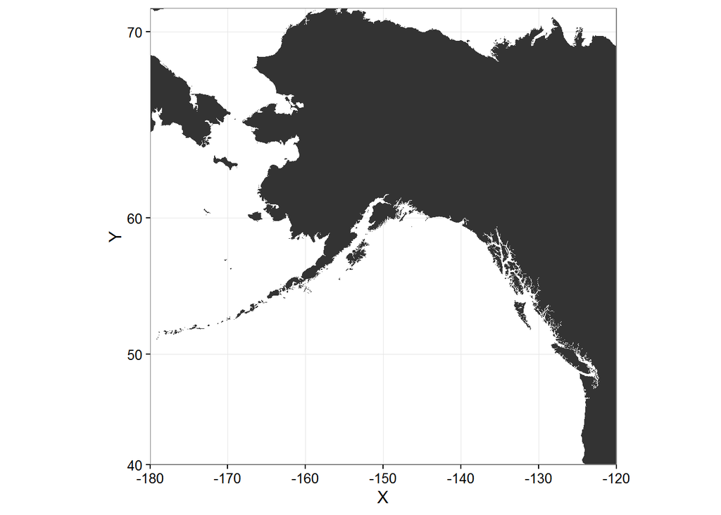

```r
insetxmin <- -180
insetxmax <- -120
insetymin <- 40
insetymax <- 71

ggplot() +
  geom_polygon(data=nepacLLhigh,aes(x=X,y=Y,group=PID)) +
  coord_map(xlim=c(insetxmin,insetxmax),ylim=c(insetymin,insetymax)) +
  theme_bw()
```

The key to an inset of course is some sort of bounding box that identifies our study region within the broader map. We can draw a rectangle that is bounded by the coordinates that we used to scale the study area map (previously called, xmin, xmax, ymin, ymax)

```r
#  Create our extent rectangle
my.extent<-data.frame(xmin=xmin,xmax=xmax,ymin=ymin,ymax=ymax)

#  This is just a data.frame with four points.
my.extent
```

```
##   xmin xmax ymin ymax
## 1 -170 -130   50   70
```

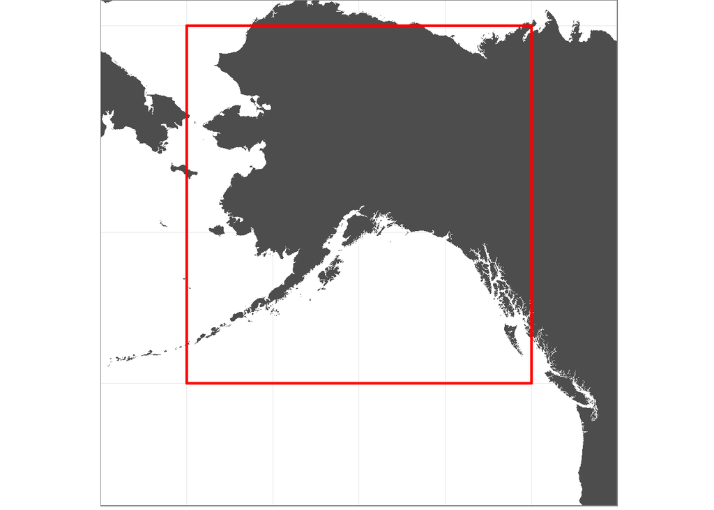

```r
#  Let's plot the inset
my.inset <- ggplot() +
  geom_polygon(data=nepacLLhigh,aes(x=X,y=Y,group=PID),fill="grey30") +
  coord_map(xlim=c(insetxmin,insetxmax),ylim=c(insetymin,insetymax)) +
  geom_rect(data = my.extent,
            aes(xmin = xmin, xmax = xmax, ymin = ymin, ymax = ymax),
            alpha=0,
            colour="red",
            size = 1,
            linetype=1) +
  theme_bw() +
  theme(axis.text=element_blank(),
        axis.ticks=element_blank(),
        plot.margin=unit(c(0,0,0,0),"mm")) +
  labs(x=NULL,y=NULL)

my.inset
```

An important note in the above settings. For the inset we don’t want any margin around the map. We have to set the x and y labels to NULL instead of just making them blank (via “”). If we set them to be blank then they are still there but you just can’t see them. If you use NULL instead, they no longer occupy that space and the margins can be brought in.

For creating the inset we’ll make use of a gridding format within the grid and gridExtra packages. Specifically, we’ll use what are called viewports. To say that I have a poor understanding of how to customize and manipulate “viewports” is an understatement. But in so far as adding an inset to your map, I can describe simply.

```r
#  Load the packages
library(grid)
library(gridExtra)
```

The grid and gridExtra packages divide the plotting space into a grid. Within the grid, we can define the plotting region by these different viewports. First we can create a new grid:

```r
grid.newpage()
```

A page can create multiple different viewports. If we wanted just a single plot to occupy the entire space, it would have a width and height of 1, centered in the middle (x and y = 0.5).

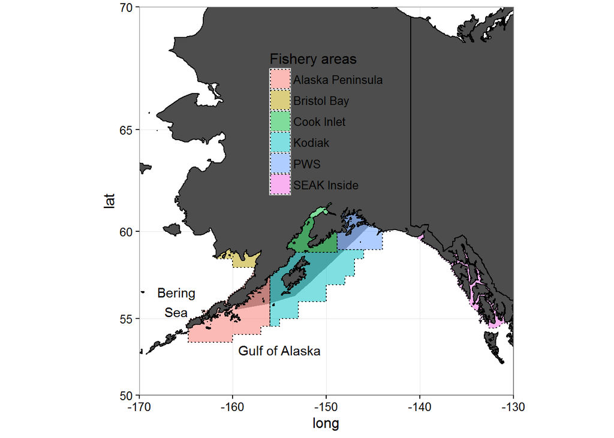

```r
v1<-viewport(width = 1, height = 1, x = 0.5, y = 0.5) #plot area for the main map
print(my.map,vp=v1)
```

In this case we want our main map to take up the whole plot, and then we want a second viewport to overlay atop the first. So we create one viewport with width/height = 1 and centered on 0.5. Then we create a second viewport where the plot is only, arbitrarily, let’s say 20% of the size of the first plot (width=0.2,height=0.2). And we want to stick in the unoccupied portion of the Gulf of Alaska in the bottom right corner. For viewports, think standard Cartesian reference system where 0,0 is the bottom left and 1,1 is the top right corner. After a bunch of fiddling, I came up with the following:

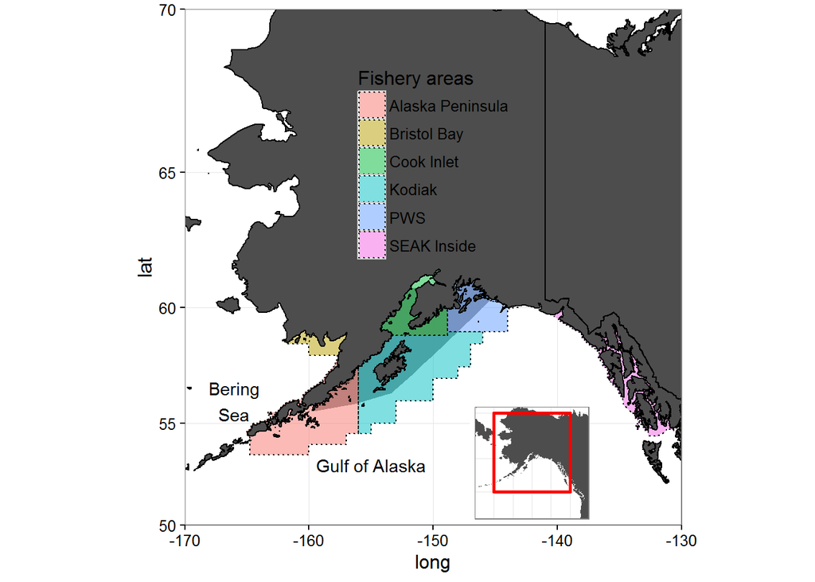

```r
grid.newpage()
v1<-viewport(width = 1, height = 1, x = 0.5, y = 0.5) #plot area for the main map
v2<-viewport(width = 0.2, height = 0.2, x = 0.65, y = 0.2) #plot area for the inset map
print(my.map,vp=v1)
print(my.inset,vp=v2)
```

We could save this directly to a file.

```r
png(file="test.png",w=1800,h=1800, res=300)
grid.newpage()
v1<-viewport(width = 1, height = 1, x = 0.5, y = 0.5) #plot area for the main map
v2<-viewport(width = 0.2, height = 0.2, x = 0.65, y = 0.2) #plot area for the inset map
print(my.map,vp=v1)
print(my.inset,vp=v2)
dev.off()
```

May you’d prefer to have the inset up in the land portion of the figure? Just change the x and y settings of v2

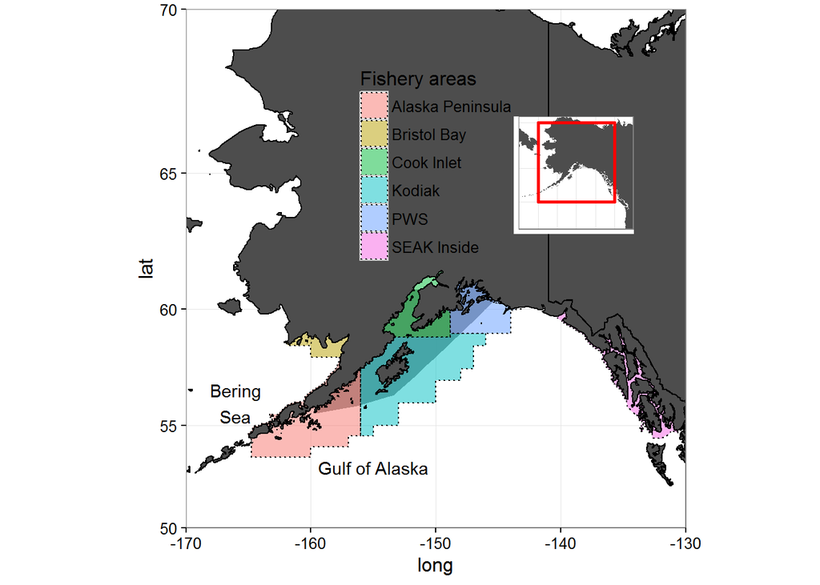

```r
grid.newpage()
v1<-viewport(width = 1, height = 1, x = 0.5, y = 0.5) #plot area for the main map
v2<-viewport(width = 0.2, height = 0.2, x = 0.7, y = 0.7) #plot area for the inset map
print(my.map,vp=v1)
print(my.inset,vp=v2)
```

This isn’t really the best inset because it’s not a whole lot broader of a region than the original map. That’s because the shapefile I used was fairly limiting. I used this one because the coordinates were on the same scale and I was being lazy. One of the annoying things with mapping Alaska is that whole dateline thing. Let’s look at two of the other built-in world data sets from the maps package.

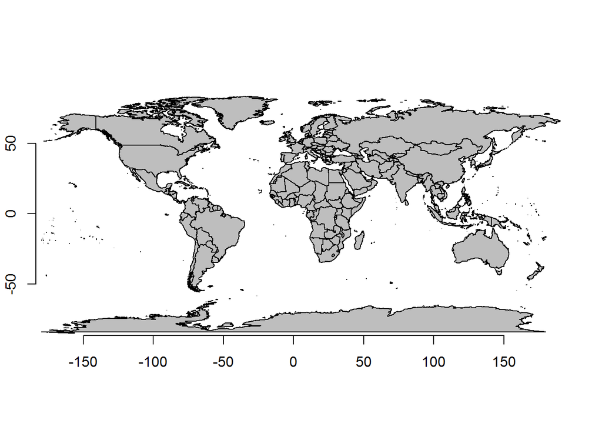

```r
library(maps)

#  The built-in maps package has a "world" and a "world2" dataset.
#  "World" is centered on the Prime Meridian
map("world",fill=TRUE,col="grey");axis(1);axis(2)
```

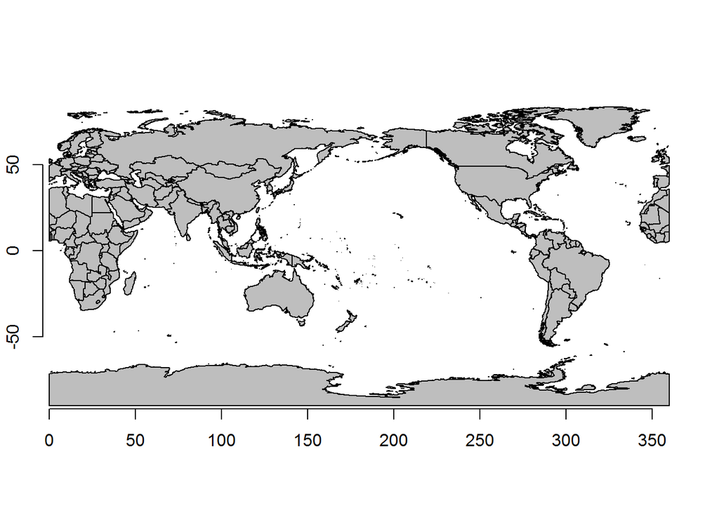

```r
#  World2 is centered on the date line
map("world2",fill=TRUE,col="grey");axis(1);axis(2)
```

Note that the x-axis on one goes from -180 to 180 and the other is 0 to 360. Our Alaska base layer map also goes from -180 to 180.

```r
range(ak$long)
```

```
## [1] -179.1473  179.7785
```

However, being on the same scale doesn’t really help us that much because if you look at the world map above that goes from -180 to 180, it cuts the Aleutian chain so that parts of it are on opposite sides of the world. We could try to do some transformations or just use the map that is already scaled for the Pacific.

```r
#  Convert this maps object into a ggplot data frame.
world2 <- map_data("world2")

#  Did it work?
class(world2)
```

```
## [1] "data.frame"
```

```r
#  What are the names of the fields?
head(world2)
```

```
##       long      lat group order region subregion
## 1 290.1009 12.45200     1     1  Aruba      <NA>
## 2 290.1043 12.42300     1     2  Aruba      <NA>
## 3 290.0578 12.43853     1     3  Aruba      <NA>
## 4 289.9958 12.50049     1     4  Aruba      <NA>
## 5 289.9339 12.54697     1     5  Aruba      <NA>
## 6 289.9491 12.59707     1     6  Aruba      <NA>
```

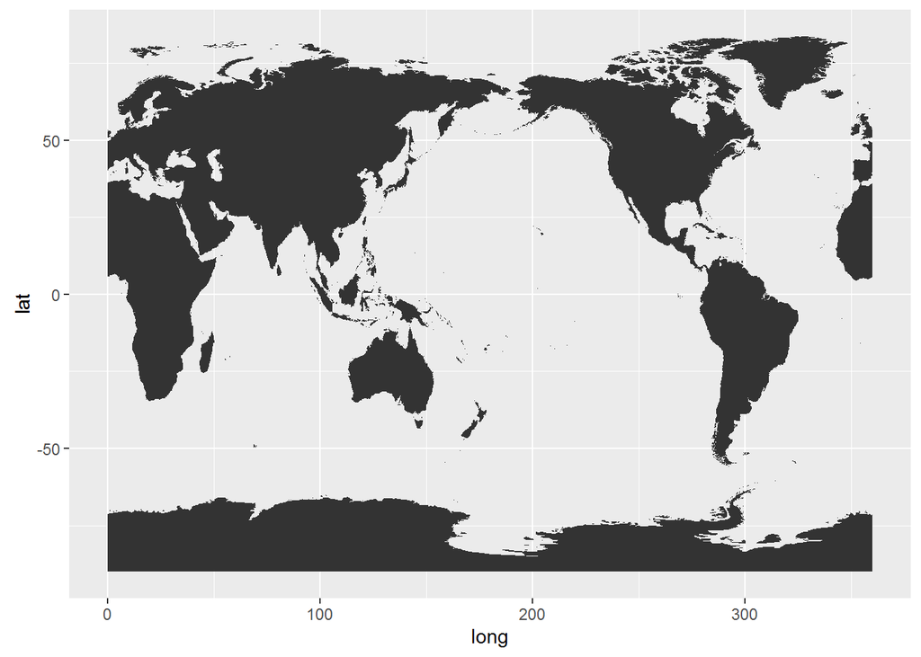

```r
#  What's it look like?
ggplot() + geom_polygon(data=world2,aes(x=long,y=lat,group=factor(group)))
```

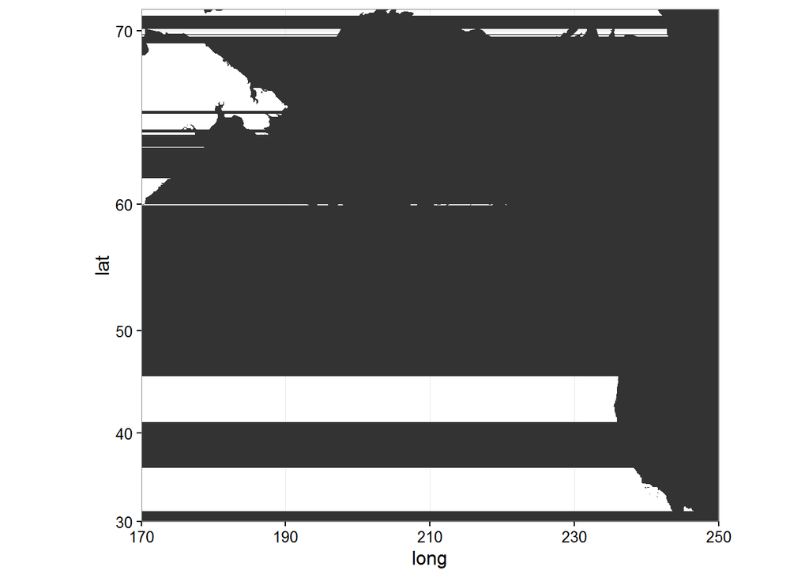

```r
#  Ideally we could just reuse some of the code from our previous inset experience.
#  First let's look at the boundaries we'd set.

insetxmin <- -180
insetxmax <- -120

#  We see pretty quickly that we've already got a probably since our
#  new map doesn't have negative longitudes. No problem.
#  We wanted new boundaries anyway, right?
#  We could just add 360 to the old boundaries to get the same extent as before

insetxmin <- -180 + 360
insetxmax <- -120 + 360

#  Or we could look at the map and just pick new bounds altogether.

insetxmin <- 170
insetxmax <- 250

#  Maybe let's expand our souther x boundary a bit, too

insetymin <- 30
insetymax <- 71

ggplot() +
  geom_polygon(data=world2,aes(x=long,y=lat,group=factor(group))) +
  coord_map(xlim=c(insetxmin,insetxmax),ylim=c(insetymin,insetymax)) +
  theme_bw()
```

Whoa! What happened? Well this is actually a common problem when you try to zoom in with the world and world2 (and some other) spatial datasets. The way I understand it is basically that we have tried to zoom in too far within a given polygon or set of polygons such that some of them are inside the plotting region and some are outside. R gets confused on how to draw the polygons when this happens. A work around is to clip the polygons to the region that we want to plot, essentially creating new polygons. We can use the clipPolys function from PBSmapping to do this (it should already be loaded because that’s where we got the nepacLLhigh dataset earlier).

First, clipPolys is expecting certain column names so we should change the names of our columns to match those. Instead of “long” and “lat”, it wants “X” and “Y”, repectively. Instead of “group” it wants “PID” and instead of “order” it uses “POS.” We can then keep the extra column names (that’s what the keepExtra=TRUE will do in clipPolys)

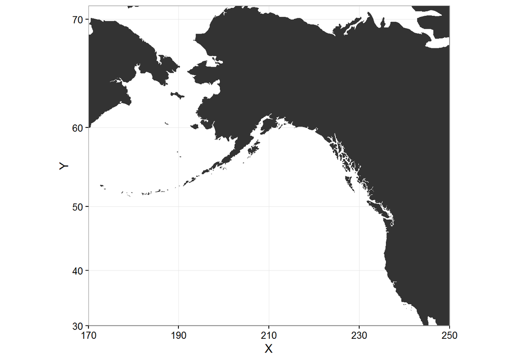

```r
names(world2) <- c("X","Y","PID","POS","region","subregion")

#  You can learn more about clipPolys via ?clipPolys.
#  We need to specify our x and y boundaries so that it can clip the dataset.
world2 <- clipPolys(world2, xlim=c(insetxmin,insetxmax),ylim=c(insetymin,insetymax), keepExtra=TRUE)

#  Now let's try plotting again, but remember we changed the
#  names so we need to change our geom_polygon
ggplot() +
  geom_polygon(data=world2,aes(x=X,y=Y,group=factor(PID))) +
  coord_map(xlim=c(insetxmin,insetxmax),ylim=c(insetymin,insetymax)) +
  theme_bw()
```

So now our inset has a bit more of Russia and the Aleutian chain and certainly enough to indicate the region and scale that we’re looking at I think.

```r
#  We want the extent rectangle to show the same area as the focus
#  map but remember they're on different scales now.
xmin
```

```
## [1] -170
```

```r
xmax
```

```
## [1] -130
```

```r
#  We can fix this by simply adding 360 to our longitudinal values.
my.extent<-data.frame(xmin=(xmin+360),xmax=(xmax+360),ymin=ymin,ymax=ymax)

my.extent
```

```
##   xmin xmax ymin ymax
## 1  190  230   50   70
```

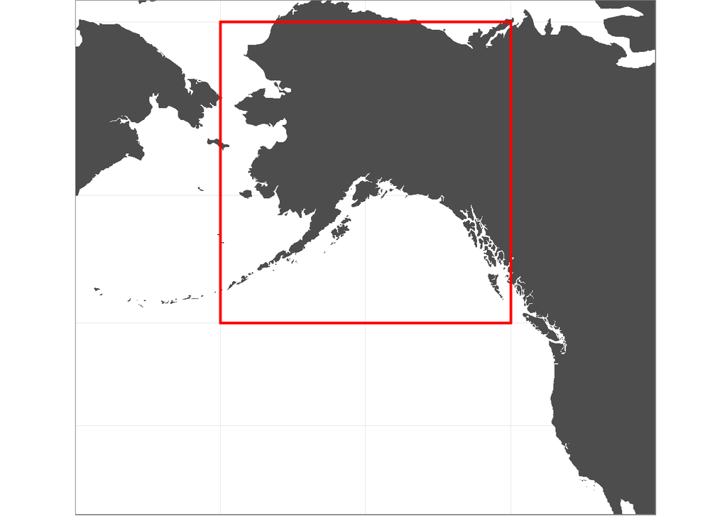

```r
my.inset <- ggplot() +
  geom_polygon(data=world2,
               aes(x=X,y=Y,group=PID),
               fill="grey30") +
  coord_map(xlim=c(insetxmin,insetxmax),
            ylim=c(insetymin,insetymax)) +
  geom_rect(data = my.extent,
            aes(xmin = xmin, xmax = xmax, ymin = ymin, ymax = ymax),
            alpha=0,
            colour="red",
            size = 1,
            linetype=1) +
  theme_bw() +
  theme(axis.text=element_blank(),
        axis.ticks=element_blank(),
        plot.margin=unit(c(0,0,0,0),"mm")) +
  labs(x=NULL,y=NULL)


my.inset
```

This spatial file is actually a little less detailed which looks better for the inset as well.

I’ll show a variation on the previous inset approach now, where we have multiple main figures and either a single or multiple insets.

Let’s use a viewport grid layout to display our color and bw maps side by side.

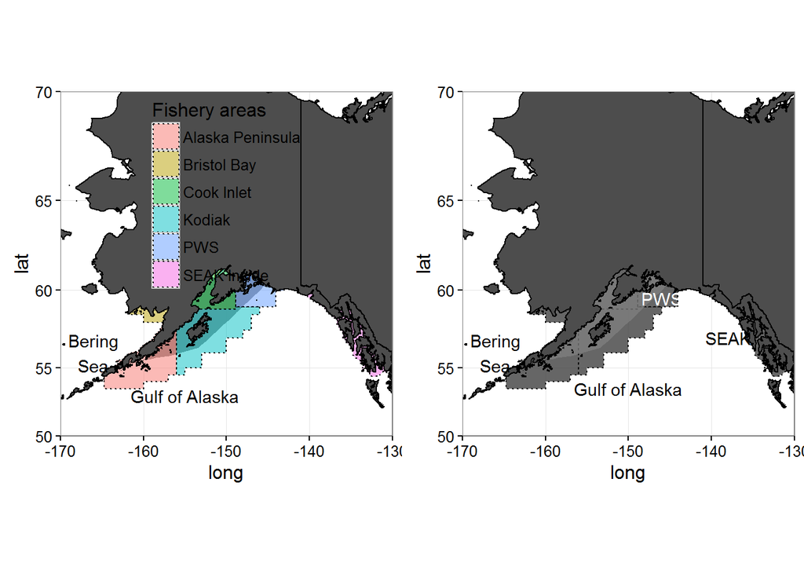

```r
grid.newpage()
pushViewport(viewport(layout = grid.layout(1, 2))) # Side by side layout (1 row x 2 columns)
#  Create a function that specifies the layout of the grid
#  (you don't have to understand this - just be able to copy and paste it)
vplayout <- function(x, y) viewport(layout.pos.row = x, layout.pos.col = y)
print(my.map, vp = vplayout(1, 1))  # Row 1, column 1
print(bw.map, vp = vplayout(1, 2))  # Row 2, column 2
```

Now let’s add an inset to the color map.

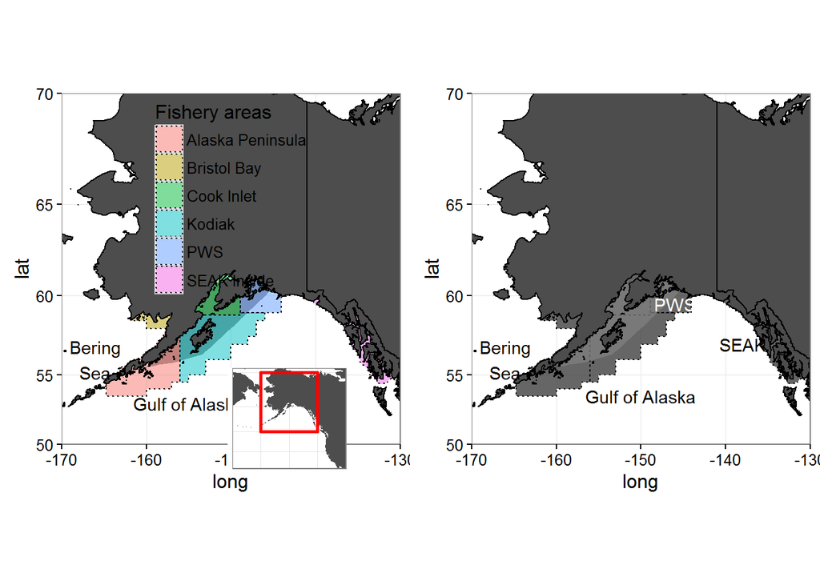

```r
grid.newpage()
pushViewport(viewport(layout = grid.layout(1, 2))) # Side by side layout
v2<-viewport(width = 0.18, height = 0.18, x = 0.35, y = 0.28) #plot area for the inset map
vplayout <- function(x, y) viewport(layout.pos.row = x, layout.pos.col = y)
print(my.map, vp = vplayout(1, 1))  # Row 1, column 1
print(bw.map, vp = vplayout(1, 2))  # Row 2, column 2
print(my.inset, vp = v2)
```

To add an inset to the second plot, we just need to create a new viewport.

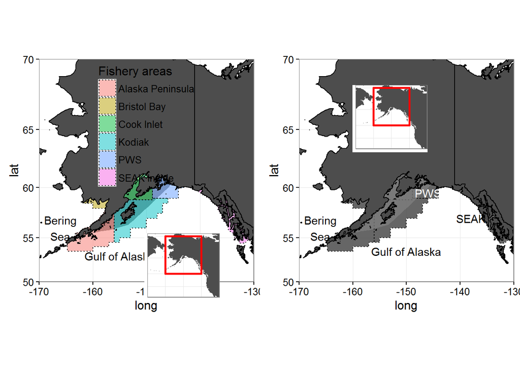

```r
grid.newpage()
pushViewport(viewport(layout = grid.layout(1, 2))) # Side by side layout
v2 <-viewport(width = 0.18, height = 0.18, x = 0.35, y = 0.28) #plot area for the inset map
v3 <- viewport(width = 0.18, height = 0.18, x = 0.75, y = 0.68)
vplayout <- function(x, y) viewport(layout.pos.row = x, layout.pos.col = y)
print(my.map, vp = vplayout(1, 1))  # Row 1, column 1
print(bw.map, vp = vplayout(1, 2))  # Row 2, column 2
print(my.inset, vp = v2)
print(my.inset, vp = v3)
```

Of course, viewports are not for maps alone. They are just another way to grid your graphics objects. We can add any old figure to the plotting region. Let’s create a dummy plot.

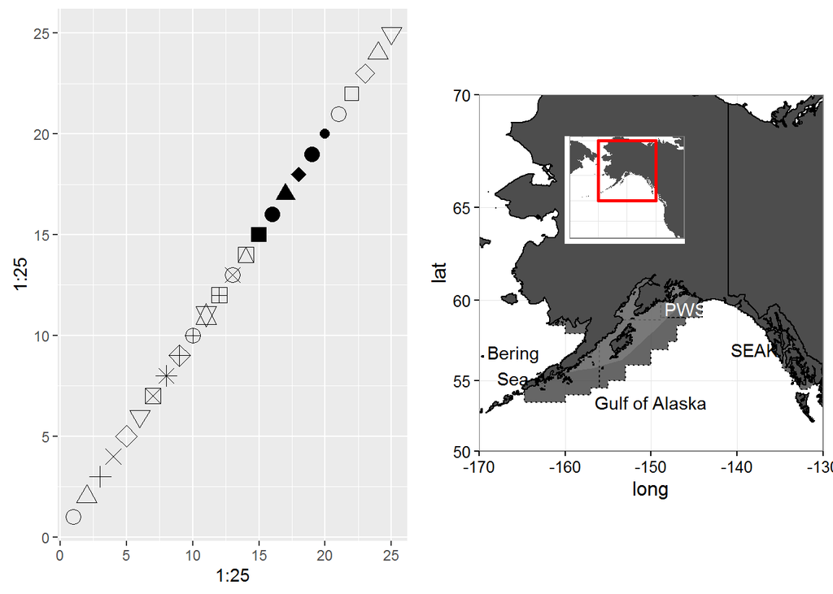

```r
p1 <- ggplot() + geom_point(aes(x=1:25,y=1:25),shape=1:25,size=4)

grid.newpage()
pushViewport(viewport(layout = grid.layout(1, 2))) # Side by side layout
v2 <-viewport(width = 0.18, height = 0.18, x = 0.35, y = 0.28) #plot area for the inset map
v3 <- viewport(width = 0.18, height = 0.18, x = 0.75, y = 0.68)
vplayout <- function(x, y) viewport(layout.pos.row = x, layout.pos.col = y)
print(p1, vp = vplayout(1, 1))  # Row 1, column 1
print(bw.map, vp = vplayout(1, 2))  # Row 2, column 2
print(my.inset, vp = v3)
```

We can just futz with the figure margins in either of the plots to get them to line up but I’m not going to worry about that here.